# Class Tasks

## L2

Task 1: genRandDNA(k) function that generates random DNA sequence of length k and returns

যা করসি: random থেকে randint function import করে ওইখানে 0 - 3 এর ভিতর Random integer generate করে ওই অনুযায়ী neucleotide set করে ছেড়ে দিসি!

```python
from random import randint

def getRandDNA(k):
    DNA = []
    for i in range (k):
        ch = randint(0, 3)
        if ch == 0:
            DNA.append('A')
        elif ch == 1:
            DNA.append('T')
        elif ch == 2:
            DNA.append('G')
        elif ch == 3:
            DNA.append('C')
    print ''.join(DNA)

getRandDNA(4)
```

```
CACT
```

Task 2: genRandRNA(k) function that generates random RNA sequence of length k and returns

যা করসি: আগেরটার মতই। random থেকে randint function import করে ওইখানে 0 - 3 এর ভিতর Random integer generate করে ওই অনুযায়ী neucleotide set করে ছেড়ে দিসি!

```python
from random import randint

def getRandRNA(k):
    RNA = []
    for i in range (k):
        ch = randint(0, 3)
        if ch == 0:
            RNA.append('A')
        elif ch == 1:
            RNA.append('U')
        elif ch == 2:
            RNA.append('G')
        elif ch == 3:
            RNA.append('C')
    print ''.join(RNA)

getRandRNA(4)
```

```
CUUC
```

Task 3: countNt(DNA,isDNA=true) function that shows nucleotide frequencies in percentage of DNA/RNA

যা করসি: একটা Dictionary নিসি যাতে A T C G key থাকবে। এরপরে একটা লুপে value initiate করে পরের লুপে কে কয়টা করে আছে কাউন্ট করে নিসি। এরপরে ঐকিক নিয়মে শতকরা হিসাব করসি। :D

পরের কোড টা আসলে good practice. প্রথমটা dictionary practice করার জন্য করসি। এখানে string এর count function দিয়ে string এ কয়বার ঐ নিউক্লিওটাইড আছে বের করে শতকরা হিসাব করসি।

```python
#Dictionary use practice
def CountNt(DNA):
    Neucleotide = {}
    possibleNeucleotides = 'ATGC'
    for i in range (len(possibleNeucleotides)):
        Neucleotide[possibleNeucleotides[i]] = 0
    for i in range (len(DNA)):
        Neucleotide[DNA[i]] += 1
    for Neucleotide, Value in Neucleotide.iteritems():
        print Neucleotide, '=', (float(Value)/float(len(DNA))*100.0), '%'

CountNt("AATTGGGGC")
```

```
A = 22.2222222222 %
C = 11.1111111111 %
T = 22.2222222222 %
G = 44.4444444444 %
```

```python
def CountNt(DNA):
    print 'A:', float(DNA.count('A'))/float(len(DNA))*100.0, "%"
    print 'T:', float(DNA.count('T'))/float(len(DNA))*100.0, "%"
    print 'G:', float(DNA.count('G'))/float(len(DNA))*100.0, "%"
    print 'C:', float(DNA.count('C'))/float(len(DNA))*100.0, "%"

CountNt("AATTGGGGC")
```

```
A: 22.2222222222 %
T: 22.2222222222 %
G: 44.4444444444 %
C: 11.1111111111 %
```

Task 4: getRevComplement(DNA,isDNA=true) function that returns complementary sequence of that DNA/RNA

যা করসি: প্রথমে DNA sequence কে উল্টায় নিসি। এরপরে একটা array তে প্রতিটা neucleotide এর জন্য complimentary neucleotide save করে শেষে ওই array টা ''.join দিয়ে প্রিন্ট করে দিসি।

```python
def getRevComplement(DNA):
    DNA = DNA[::-1]
    reverse = []
    for neucleotide in DNA:
        if neucleotide == 'A':
            reverse.append('T')
        elif neucleotide == 'T':
            reverse.append('A')
        elif neucleotide == 'C':
            reverse.append('G')
        elif neucleotide == 'G':
            reverse.append('C')
    print ''.join(reverse)

getRevComplement("AAAACCCGGT")
```

```
ACCGGGTTTT
```

Task 5: convDNAtoRNA(DNA) function converts DNA to RNA

যা করসি: DNA এর ভিতর T থাকলে U করে দিসি।

```python
def convDNAtoRNA(DNA):
    RNA = []
    for i in range(len(DNA)):
        if DNA[i] == 'T':
            RNA.append('U')
        else:
            RNA.append(DNA[i])
    print ''.join(RNA)

convDNAtoRNA("ATGC")
```

```
AUGC
```

## L3

Task 2: Read the E.coli genome and show nucleotide frequencies in percentage

মনে রাখার জিনিসঃ ক্যামনে ফাইল ওপেন করে Sequence read করে সেইটা। with open("GCF_000005845.2_ASM584v2_genomic.fna", "r") as inFile: এরপরে লুপে একটার পর একটা লাইন আসবে।

কি করসিঃ এখানে string এর count function দিয়ে string এ কয়বার ঐ নিউক্লিওটাইড আছে বের করে শতকরা হিসাব করসি।

```python
def CountNt(DNA):
    print 'A:', float(DNA.count('A'))/float(len(DNA))*100.0
    print 'T:', float(DNA.count('T'))/float(len(DNA))*100.0
    print 'G:', float(DNA.count('G'))/float(len(DNA))*100.0
    print 'C:', float(DNA.count('C'))/float(len(DNA))*100.0

seq = ''
count = 0
with open("GCF_000005845.2_ASM584v2_genomic.fna", "r") as inFile:
    for line in inFile:
        if count == 0:
            count = 1
        else:
            seq += line
CountNt(seq)
```

```
A: 24.3153513021
T: 24.2864131185
G: 25.0535941543
C: 25.1100661684
```

Task 3: Repeat Task 2 using Bio function আমার মনে হচ্ছে এইটা করা মানে সময় নষ্ট। বায়ো ফাংশন লাগবে না। আমি নিজেই পারি এইটা। -_-

Task 4: Rosalind BA1A একটা DNA string এ একটা প্যাটার্ন কয়বার আছে কাউন্ট করতে হবে।

কি করসিঃ স্ট্রিং এর ভিতর একটার পর একটা ক্যারেক্টার রিড করে করে আগাইসি। প্যাটার্নের সমান সাবস্ট্রিং নিয়ে চেক করসি প্যাটার্নের সাথে ম্যাচ করে কিনা। যদি করে কাউন্টের ভ্যালু বাড়ায় নিসি জাস্ট।

পরের কোডটায় চুরি করতে নিসিলাম। কাজ করে না। এই জিনিস করলে বাঁশ রেডি!

```python
def PatternCount(DNA, pattern):
    count = 0
    for i in range(len(DNA)-len(pattern)+1):
        if DNA[i:i+len(pattern)] == pattern:
            count += 1
    print count

PatternCount("GCGCG","GCG")
```

```
2
```

```python
def PatternCount(DNA, pattern):
    print DNA.count(pattern)

PatternCount("GCGCG","GCG")
```

```
1
```

Task 5: Rosalind BA1B সবচাইতে frequent k length এর প্যাটার্ন বাইর করতে হবে।

কি করসিঃ Dictionary তে প্রতিটা k mer কয়বার করে আছে সেটা রাখসি। সবচাইতে বেশি ভ্যালু পাইসি যেইটায় সেইটা প্রিন্ট করে দিসি! :D Sorry for the variable slang! :D

```python
def ferqWord(text, k):
    dick = {} #-_-
    for i in range(len(text)-k+1):
        dick[text[i:i+k]] = 0
    for i in range(len(text)-k+1):
        dick[text[i:i+k]] += 1
    maxval = 0
    for key, value in dick.iteritems():
        if value > maxval:
            maxval = value
    for key, value in dick.iteritems():
        if value == maxval:
            print key,

ferqWord("ACGTTGCATGTCGCATGATGCATGAGAGCT",4)
```

```
CATG GCAT
```

Task 6: Rosalind BA1D একটা প্যাটার্ন একটা স্ট্রিং এর কোন কোন পজিশনে আছে বলতে হবে।

কি করসিঃ প্রতিটা pattern length এর substring নিয়ে চেক করসি ম্যাচ করে কিনা। করলে পজিশন প্রিন্ট করে দিসি।

```python
def patternOccur(text, pattern):
    for i in range(len(text) - len(pattern) + 1):
        if text[i:i+len(pattern)] == pattern:
            print i,

patternOccur("GATATATGCATATACTT","ATAT")
```

```
1 3 9
```

Task 7: Rosalind BA1E (L, t) Clump Finding problem একটা বিশাল String দিবে। ওইটায় L size এর window তে একটা kmer যদি t বা তার বেশি সংখ্যক বার থাকে তাইলে সেইটা প্রিন্ট করতে হবে। এইটা আসার পসিবিলিটি খুবই বেশি।

কি করসিঃ

```python
def PatternCount(DNA, pattern):
    count = 0
    for i in range(len(DNA)-len(pattern)+1):
        if DNA[i:i+len(pattern)] == pattern:
            count += 1
    return count


def clumpFinding(DNA, k, L, t):
    res = []
    for i in range(len(DNA)-L+1):
        window = DNA[i:i+L]
        for j in range(L-k+1):
            clump = window[j:j+k]
            if PatternCount(window, clump) >= t:
                if clump not in res:
                    res.append(clump)
    print ' '.join(res)

clumpFinding("CGGACTCGACAGATGTGAAGAAATGTGAAGACTGAGTGAAGAGAAGAGGAAACACGACACGACATTGCGACATAATGTACGAATGTAATGTGCCTATGGC", 5, 75, 4)
```

```
CGACA GAAGA AATGT
```

## L4

Task 1: BA1F G-C বের করতে হবে

```python
def minSkew(DNA):
    gminc = []
    G = 0
    C = 0
    for i in range(len(DNA)):
        if DNA[i] == 'G':
            G += 1
        elif DNA[i] == 'C':
            C += 1
        gminc.append(G-C)
    minskew = min(gminc)
    for i in range(len(gminc)):
        if gminc[i] == minskew:
            print i+1,

minSkew("CCTATCGGTGGATTAGCATGTCCCTGTACGTTTCGCCGCGAACTAGTTCACACGGCTTGATGGCAAATGGTTTTTCCGGCGACCGTAATCGTCCACCGAG")
```

```
53 97
```

Task 2: function skewDiagram(dna) that draws skew diagram -- Show skew diagram for E.coli

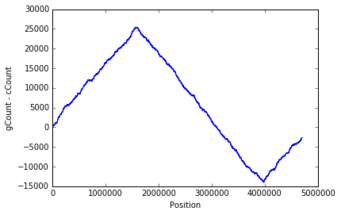

```python
%matplotlib inline
import matplotlib.pyplot as plt

def minSkew(DNA):
    gminc = []
    G = 0
    C = 0
    xvals = []
    for i in range(len(DNA)):
        if DNA[i] == 'G':
            G += 1
        elif DNA[i] == 'C':
            C += 1
        gminc.append(G-C)
        xvals.append(i)
    plt.plot(xvals,gminc)
    plt.ylabel('gCount - cCount')
    plt.xlabel('Position')
    plt.show()

seq = ''
count = 0
with open("GCF_000005845.2_ASM584v2_genomic.fna", "r") as inFile:
    for line in inFile:
        if count == 0:
            count = 1
        else:
            seq += line
minSkew(seq)
```

Task 3: BA1G

```python
def hammingDistance(str1, str2):
    dist = 0
    for i in range(len(str1)):
        if str1[i] != str2[i]:
            dist += 1
    print dist

hammingDistance("GGGCCGTTGGT", "GGACCGTTGAC")
```

```
3
```

Task 4: BA1J #Try again from Rafi's (সমস্যা আছে এখনো)

```python
def hammingDistance(str1, str2):
    dist = 0
    for i in range(len(str1)):
        if str1[i] != str2[i]:
            dist += 1
    return dist

def getRevComplement(DNA):
    DNA = DNA[::-1]
    reverse = []
    for neucleotide in DNA:
        if neucleotide == 'A':
            reverse.append('T')
        elif neucleotide == 'T':
            reverse.append('A')
        elif neucleotide == 'C':
            reverse.append('G')
        elif neucleotide == 'G':
            reverse.append('C')
    return ''.join(reverse)

def PatternCount(text, pattern, d):
    count = 0
    for i in range(len(text)-len(pattern)+1):
        txt = text[i:i+len(pattern)]
        if hammingDistance(txt, pattern) <= d:
            count += 1
    return count

def ferqWordWithMismatch(text, k, m):
    kmers = {}
    for i in range(len(text)-k+1):
        maintext = text[i:i+k]
        revtext = getRevComplement(text)
        kmers[maintext] = PatternCount(text, maintext, m) + PatternCount(text, revtext, m)
    maxval = max(kmers.values())
    for key, value in kmers.iteritems():
        if value == maxval:
            print key, getRevComplement(key), value

ferqWordWithMismatch("ACGTTGCATGTCGCATGATGCATGAGAGCT", 4, 1)
```

```
ATGC GCAT 5
ATGT ACAT 5
GATG CATC 5
```

```python
def hammingDistance(DNA1,DNA2):
    cnt = 0
    for i in range (len(DNA1)):
        if DNA1[i] != DNA2[i]:
            cnt = cnt + 1
    return cnt

def PatternCount(Text, Pattern, d):
    count = 0
    length = len(Pattern)
    for i in range (len(Text)-len(Pattern)+1):
        str = Text[i:i+length]
        hd = hammingDistance(str,Pattern)
        if hd <=d:
            count = count + 1
    return count

Text = "ACGTTGCATGTCGCATGATGCATGAGAGCT"
k = 4
d = 1
hd = 0
kmers = {}
for i in range (len(Text)-4+1):
    str = Text[i:i+4]
    #strrev = str[::-1]
    strrev = []
    for j in range (len(str)):
        if str[j] == 'A':
            strrev.append('T')
        elif str[j] == 'T':
            strrev.append('A')
        elif str[j] == 'G':
            strrev.append('C')
        elif str[j] == 'C':
            strrev.append('G')
    strrev = strrev[::-1]
    hd = PatternCount(Text,str,d) + PatternCount(Text,strrev,d)
    kmers[str] = hd
# max(kmers.items(), key=lambda x: x[1])
# dict.get(key, default=None)
mx = max(kmers.values())
for key,value in kmers.iteritems():
    if value==mx:
        print key, value
```

```
ATGT 9
```

Task 5: BA1N

```python
import itertools

def hammingDistance(DNA1,DNA2):
    cnt = 0
    for i in range (len(DNA1)):
        if DNA1[i] != DNA2[i]:
            cnt = cnt + 1
    return cnt

def dNeighbour(pattern, d):
    bases = ['A', 'T', 'G', 'C']
    combinations = [''.join(p) for p in itertools.product(bases, repeat=len(pattern))]
    for i in combinations:
        if hammingDistance(pattern, i) <= d:
            print i

dNeighbour("ACG", 1)
```

```
AAG
ATG
AGG
ACA
ACT
ACG
ACC
TCG
GCG
CCG
```

Task 6: BA2B

```python
import itertools

def hammingDistance(DNA1,DNA2):
    cnt = 0
    for i in range (len(DNA1)):
        if DNA1[i] != DNA2[i]:
            cnt = cnt + 1
    return cnt

def minHammingDistancePattern(text, pattern):
    minHammingDistance = 99999
    for i in range(len(text)-len(pattern)+1):
        if hammingDistance(text[i:i+len(pattern)], pattern) < minHammingDistance:
            minHammingDistance = hammingDistance(text[i:i+len(pattern)], pattern)
    return minHammingDistance

def medianString(k, patterns):
    kmers = {}
    combinations = [''.join(p) for p in itertools.product("ATGC", repeat = k)]
    for combination in combinations:
        patternSum = 0
        for dna in patterns:
            patternSum += minHammingDistancePattern(dna, combination)
        kmers[combination] = patternSum
    for key, value in kmers.iteritems():
        if value == min(kmers.values()):
            print key,

patterns = ["AAATTGACGCAT","GACGACCACGTT","CGTCAGCGCCTG","GCTGAGCACCGG","AGTACGGGACAG"]
medianString(3, patterns)
```

```
ACG GAC
```

Task 7: BA2C

```python
def ProfileMostProbableKmer(DNA, k, profile):
    profiles = {}
    for i in range(len(DNA)-k+1):
        probability = 1.0
        pattern = DNA[i:i+k]
        for j in range(len(pattern)):
            if pattern[j] == 'A':
                probability = probability * profile[0][j]
            elif pattern[j] == 'C':
                probability = probability * profile[1][j]
            elif pattern[j] == 'G':
                probability = probability * profile[2][j]
            elif pattern[j] == 'T':
                probability = probability * profile[3][j]
        profiles[pattern] = probability
    for key, value in profiles.iteritems():
        if value == max(profiles.values()):
            print key,


DNA="ACCTGTTTATTGCCTAAGTTCCGAACAAACCCAATATAGCCCGAGGGCCT"
k=5
profile = [
    [0.2, 0.2, 0.3, 0.2, 0.3],
    [0.4, 0.3, 0.1, 0.5, 0.1],
    [0.3, 0.3, 0.5, 0.2, 0.4],
    [0.1, 0.2, 0.1, 0.1, 0.2]
]
ProfileMostProbableKmer(DNA, k, profile)
```

```
CCGAG
```

Task 8: BA2F Randomized Motif Search পারি নাই

Task 9: BA2G GibbsSampler পারি নাই

## L5 এ L4 এর Chapter 2 এর হাবিজাবিই দিসিলো

## L6

Task 1: BA3A K-mer Composition বের করতে হবে

```python
def kmerComposition(text, k):
    kmer = []
    for i in range(len(text)-k+1):
        kmer.append(text[i:i+k])
    kmer.sort()
    print '\n'.join(kmer)

kmerComposition("CAATCCAAC", 5)
```

```
AATCC
ATCCA
CAATC
CCAAC
TCCAA
```

Task 2: BA3E Construct the De Bruijn Graph of a Collection of k-mers

যা করসিঃ kmer গুলা sort করে নিয়ে একটা dictionary তে প্রত্যেকটা prefix key তে suffix গুলা append করে দিলেই চলবে

মনে রাখতে হবেঃ dictionary তে ক্যামনে string add করে একটা key এর বিপরীতে ডিকশনারির নাম.setdefault(চাবি,[]).append(যেই স্ট্রিং ঢুকাইতে হবে)

```python
def deBruijn(kmers):
    kmers.sort()
    nodes = {}
    for kmer in kmers:
        nodes.setdefault(kmer[0:len(kmer)-1],[]).append(kmer[1:len(kmer)])
    for key, value in nodes.iteritems():
        print key, '->', ', '.join(value)

kMers = ["GAGG", "CAGG", "GGGG", "GGGA", "CAGG", "AGGG", "GGAG"]
deBruijn(kMers)
```

```
AGG -> GGG
GAG -> AGG
GGG -> GGA, GGG
CAG -> AGG, AGG
GGA -> GAG
```

Task 3: BA3H Reconstruct a String from its k-mer Composition

```python
def Reconstruct(k, kmers):
    start = ""
    prefixes = []
    suffixes = []
    finalstr = []
    for kmer in kmers:
        prefixes.append(kmer[0:k-1])
        suffixes.append(kmer[1:k])
    for prefix in prefixes:
        if prefix not in suffixes:
            start = prefix
    finalstr.append(start)
    for i in range(len(kmers)):
        for kmer in kmers:
            if kmer[0:len(kmer)-1]==start:
                finalstr.append(kmer[len(kmer)-1:len(kmer)])
                start = kmer[1:len(kmer)]
                kmers.remove(kmer)
    print ''.join(finalstr)
kmers = ["CTTA","ACCA","TACC","GGCT","GCTT","TTAC"]
Reconstruct(4, kmers)
```

```
GGCTTACCA
```

Task 4: BA3I Find a k-Universal Circular String পারিনা

Task 5: BA3J Reconstruct a String from its Paired Composition এইটা আসলে সব কেসে কাজ করবে না। যেমন এই কেসেই কাজ করবে না। তারপরেও জোড়াতালি দিয়ে থুইসি।

```python
def ReconstructStr(k, kmers):
    start = ""
    prefixes = []
    suffixes = []
    finalstr = []
    for kmer in kmers:
        prefixes.append(kmer[0:k-1])
        suffixes.append(kmer[1:k])
    #print prefixes
    #print suffixes
    for prefix in prefixes:
        if prefix not in suffixes:
            start = prefix
    #print start
    finalstr.append(start)
    for i in range(len(kmers)):
        for kmer in kmers:
            if kmer[0:len(kmer)-1]==start:
                finalstr.append(kmer[len(kmer)-1:len(kmer)])
                start = kmer[1:len(kmer)]
                kmers.remove(kmer)
    print finalstr
    print ''.join(finalstr)

def ReconstructDuo(pairs):
    pair1 = []
    pair2 = []
    node = []
    for pair in pairs:
        node = pair.split("|")
        pair1.append(node[0])
        pair2.append(node[1])
    kmers = pair1
    for pair in pair2:
        if pair not in kmers:
            kmers.append(pair)
    ReconstructStr(len(kmers[0]),kmers)

pairs = ["GAGA|TTGA","TCGT|GATG","CGTG|ATGT","TGGT|TGAG","GTGA|TGTT","GTGG|GTGA","TGAG|GTTG","GGTC|GAGA","GTCG|AGAT"]
ReconstructDuo(pairs)
```

[output not shown]

## L7

Task 1: BA4C [print with suppeptide]

মনে রাখতে হবেঃ from itertools import cycle,islice

```
    for i in range (1,len(peptide)):
    for j in range(len(peptide)):
        c = cycle(peptide)
        val=list(islice(c,j,j+i))
        print val
        peptides.append(''.join(val))
        values.append(getTotalMass(val))
```

```python
from itertools import cycle,islice
values={'G':57,'A':71,'S':87,'P':97,'V':99,'T':101,'C':103,'I':113,'L':113,'N':114,'D':115,'K':128,'Q':128,'E':129,'M':131,'H':137,'F':147,'R':156,'Y':163,'W':186}

def getTotalMass(peptidestr):
    total = 0
    for i in peptidestr:
        total+=values[i]
    return total

def getTheoreticalSpectrum(peptide):
    peptides=[]
    values=[]
    for i in range (1,len(peptide)):
        for j in range(len(peptide)):
            c = cycle(peptide)
            val=list(islice(c,j,j+i))
            print val
            peptides.append(''.join(val))
            values.append(getTotalMass(val))
    peptides.append(peptide)
    values.append(getTotalMass(peptide))
    values.append(0)
    values.sort()
    for i in range(len(values)):
        if i == 0:
            print '$ :'+str(0)+", ",
            continue;
        print peptides[i-1]+" :"+str(values[i])+", ",

peptidecode = 'LEQN'
getTheoreticalSpectrum(peptidecode)
```

```
['L']
['E']
['Q']
['N']
['L', 'E']
['E', 'Q']
['Q', 'N']
['N', 'L']
['L', 'E', 'Q']
['E', 'Q', 'N']
['Q', 'N', 'L']
['N', 'L', 'E']
$ :0,  L :113,  E :114,  Q :128,  N :129,  LE :227,  EQ :242,  QN :242,  NL :257,  LEQ :355,  EQN :356,  QNL :370,  NLE :371,  LEQN :484,
```

```python
#Practice
from itertools import cycle,islice

def getCycle(peptide):
    peptides = []
    values = []
    for i in range(1,len(peptide)):
        for j in range(len(peptide)):
            c = cycle(peptide)
            val = list(islice(c,j,j+i))
            print val

getCycle("LEQN")
```

```
['L']
['E']
['Q']
['N']
['L', 'E']
['E', 'Q']
['Q', 'N']
['N', 'L']
['L', 'E', 'Q']
['E', 'Q', 'N']
['Q', 'N', 'L']
['N', 'L', 'E']
```

Task 2: BA4D [plot mass vs count]

```
14712706211
```

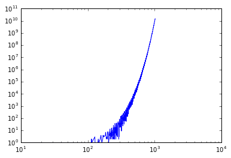

```python
%matplotlib inline
import matplotlib.pyplot as plt

values={'G':57,'A':71,'S':87,'P':97,'V':99,'T':101,'C':103,'I':113,'L':113,'N':114,'D':115,'K':128,'Q':128,'E':129,'M':131,'H':137,'F':147,'R':156,'Y':163,'W':186}
val = set(values.values())

def peptideCount(M):
    counter = {0:1}
    for i in range (M - min(val) + 1):
        j = i + min(val)
        for v in val:
            if j-v in counter:
                counter[j] = counter.get(j,0) + counter[j-v]
    print counter[M]
    x = []
    y = []
    for key in counter:
        x.append(key)
        y.append(counter[key])
    plt.plot(x,y)
    plt.xscale('log')
    plt.yscale('log')
    plt.show()

peptideCount(1024)
```

Task 4: BA4H

```python
import sys
import operator
from collections import defaultdict

def convoluteSpectrum(spectrum):
    dic = {}
    for i in range(len(spectrum)):
        for j in range(len(spectrum)):
            if spectrum[i]-spectrum[j] >= 0:
                dic[spectrum[i]-spectrum[j]] = 0
    for i in range(len(spectrum)):
        for j in range(len(spectrum)):
            if spectrum[i]-spectrum[j] >= 0:
                dic[spectrum[i]-spectrum[j]] += 1
    sorted(dic.items())
    for key, value in dic.iteritems():
        if key>0:
            for i in range(value):
                print key,

convoluteSpectrum([0, 137, 186, 323])
```

```
137 137 186 186 323 49
```

## L8

Task 2: 5C LCS বের করা

```python
import py_common_subseq

def lcs(dna1, dna2):
    subseqs = py_common_subseq.find_common_subsequences(dna1, dna2)
    maxlen = 0
    maxseq = ""
    for seq in subseqs:
        if len(seq)>maxlen:
            maxlen = len(seq)
            maxseq = seq
    print maxseq

lcs("AACCTTGG","ACACTGTGA")
```

```
AACTGG
```

## হাবিজাবি

Global Alignment

```python
from Bio import pairwise2
from Bio.SubsMat import MatrixInfo as matlist

def globalAlign(dna1, dna2):
    matrix = matlist.blosum62
    for a in pairwise2.align.globaldx(dna1, dna2, matrix):
        alignment = a
    str1 = alignment[0]
    str2 = alignment[1]
    score = alignment[2]
    for i in range (len(str1)):
        if str1[i] == '-':
            score -= 5
        elif str2[i] == '-':
            score -= 5
    print int(score)
    print str1
    print str2

globalAlign("PLEASANTLY", "MEANLY")
```

```
8
PLEASANTLY
-MEA--N-LY
```

Burrows-Wheeler

```python
def bw_transform(s):
    n = len(s)
    m = sorted([s[i:n]+s[0:i] for i in range(n)])
    transfromeds = ''.join([q[-1] for q in m])
    print transfromeds

bw_transform("GCGTGCCTGGTCA$")
```

```
ACTGGCT$TGCGGC
```